# Homework 3

Burcu Oral

22 11 2019

Firs the consumption data between 1 January 2016 to 21 November 2019 is downloaded from EPIAS and then the data till 1 November 2019 is used as train set whereas data from 1 November is used for predictions and error estimation.

## TASK A

For first task the 2 days and 7 days ago values are used as predictions. Hence the separetly lag48 and lag168 values will be equal to predictions and calculated mape values for using lag 48 and lag 168 are as follows:

```
## [1] 7.772251
```

```
## [1] 2.835292
```

## TASK B

For second task using lag 48 and lag 168 as features a linear model is fitted with coefficients for lag48 and lag168 as follows and mape value as :

```
##
## Call:
## lm(formula = train_results ~ ., data = train_data)
##
## Residuals:
##      Min       1Q   Median       3Q      Max
## -16784.6   -994.2      2.9   1022.4  15951.4
##
## Coefficients:
##              Estimate Std. Error t value Pr(>|t|)
## (Intercept) 1.624e+03  9.678e+01   16.78   <2e-16 ***
## lag_48      3.257e-01  3.520e-03   92.51   <2e-16 ***
## lag_168     6.246e-01  3.518e-03  177.51   <2e-16 ***
## ---
## Signif. codes:  0 '***' 0.001 '**' 0.01 '*' 0.05 '.' 0.1 ' ' 1
##
## Residual standard error: 2403 on 33405 degrees of freedom
## Multiple R-squared:  0.7627, Adjusted R-squared:  0.7627
## F-statistic: 5.368e+04 on 2 and 33405 DF,  p-value: < 2.2e-16
```

```
##  (Intercept)       lag_48      lag_168
## 1623.7674535    0.3256789    0.6245576
```

```
## [1] 4.010884
```

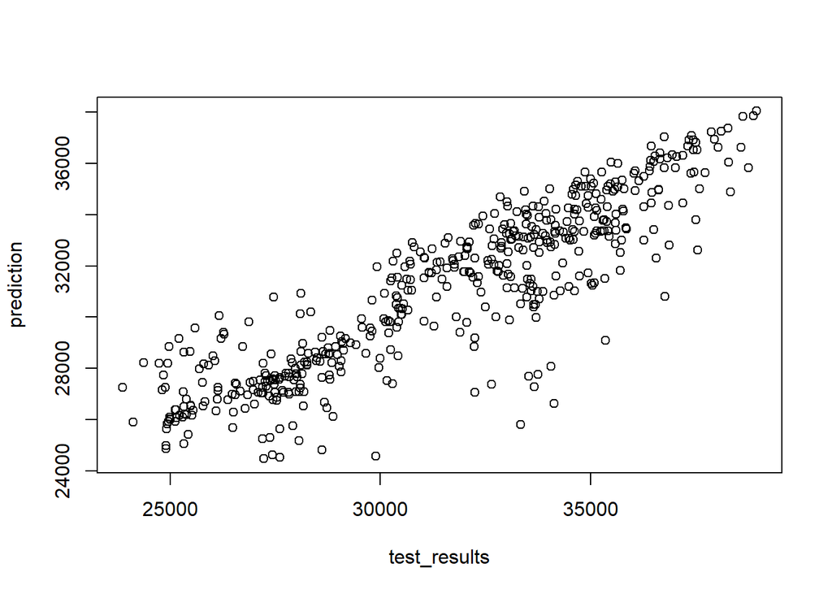

As the plot shows, test results are in agreement with predictions. R2 value is around 0.75 which suggests that the fit is not very bad. When we look at the coefficients 1 week ago consumption predictor has more importance in predicting as expected.

## TASK C

For third task all hour values are filtered and their lag_48, lag_168 and consumption values are stored and then each hour is used as predictors for the same hour in linear regression mode with coefficients and mape values as:

```
##             (Intercept)  lag_48_0 lag_168_0
## coef_hour0     2395.497 0.5027741 0.4199039
## coef_hour1     2314.151 0.5071343 0.4141683
## coef_hour2     2377.518 0.5088421 0.4071694
## coef_hour3     2425.915 0.5016380 0.4104232
## coef_hour4     2455.139 0.4829206 0.4270050
## coef_hour5     2658.024 0.4455628 0.4562593
## coef_hour6     2677.829 0.3761580 0.5253413
## coef_hour7     2935.676 0.2655975 0.6315328
## coef_hour8     4045.416 0.1752571 0.6990242
## coef_hour9     4415.793 0.1791245 0.6926641
## coef_hour10    4513.123 0.2130286 0.6588409
## coef_hour11    4682.158 0.2347045 0.6343789
## coef_hour12    4111.842 0.2943092 0.5865466
## coef_hour13    4171.138 0.3214071 0.5589320
## coef_hour14    4434.231 0.2746996 0.6005368
## coef_hour15    4342.895 0.2703456 0.6070331
## coef_hour16    4253.470 0.2597887 0.6204671
## coef_hour17    3857.854 0.2742234 0.6173082
## coef_hour18    3560.144 0.3427455 0.5570966
## coef_hour19    3791.564 0.3922826 0.5013891
## coef_hour20    3232.112 0.4193216 0.4899059
## coef_hour21    3013.126 0.4409094 0.4729729
## coef_hour22    3230.637 0.4549657 0.4509988
## coef_hour23    2857.294 0.4647505 0.4484057
```

```
## [1] 13.2935
```

The coefficients suggest that in 1 week ago estimations the peak hours (day consumption) between 9 and 17 has more importance in the estimation of consumption.

## TASK D

Both train and test data are converted into wide format and the features are used as predictors in penalized regression mode with lambda value found by 10-fold cross validation. The lambda values, coefficients and mape value are:

```
##     Hour           Lambdas
## 1  00:00 0.531560829893553
## 2  01:00  0.67773424349525
## 3  02:00 0.443442062877012
## 4  03:00 0.615645958771575
## 5  04:00 0.305993441587713
## 6  05:00 0.637681244329302
## 7  06:00 0.535568702646232
## 8  07:00 0.794857788563951
## 9  08:00  1.08267830202157
## 10 09:00  1.58765399360356
## 11 10:00  1.84515482879056
## 12 11:00  1.99993003856711
## 13 12:00  1.06878962904605
## 14 13:00  0.98153729932917
## 15 14:00 0.871465938442105
## 16 15:00  1.39595939405684
## 17 16:00  1.15277340673354
## 18 17:00 0.835306321078605
## 19 18:00 0.500979286572422
## 20 19:00 0.517522326458348
## 21 20:00   0.4912474128052
## 22 21:00 0.406176044596124
## 23 22:00 0.459266621089424
## 24 23:00   0.5553651894377
```

```
##            Hour 0 prediction Hour 1 prediction Hour 2 prediction
## lag_48_0       -0.3512834616     -4.806209e-01     -0.5793976953
## lag_168_0       0.0813887849      0.000000e+00     -0.0401031582
## lag_48_1       -0.1730029406     -2.220305e-01     -0.3825046198
## lag_168_1       0.0993022690      2.291218e-02     -0.0007830616
## lag_48_2       -0.1723004401     -4.166194e-02     -0.0240475943
## lag_168_2      -0.1704573376     -2.194907e-02     -0.0167264070
## lag_48_3        0.0000000000      1.517885e-01      0.2762012043
## lag_168_3      -0.0065599758      0.000000e+00      0.0393051821
## lag_48_4        0.4868550592      4.161380e-01      0.6168630532
## lag_168_4       0.0000000000     -1.195400e-02     -0.0010622515
## lag_48_5        0.0000000000      0.000000e+00      0.0000000000
## lag_168_5       0.0000000000     -4.628343e-05      0.0000000000
## lag_48_6       -0.0079971113     -2.225435e-02     -0.0486065409
## lag_168_6       0.1928680444      1.793000e-01      0.1271871071
## lag_48_7        0.4352251353      4.306588e-01      0.3571987358
## lag_168_7       0.2438410499      2.467763e-01      0.3015524140
## lag_48_8        0.0000000000      2.984461e-02      0.0753040919
## lag_168_8       0.0000000000      0.000000e+00      0.0221778447
## lag_48_9       -0.5961451497     -5.957174e-01     -0.5701081887
## lag_168_9      -0.0988676223     -8.894144e-02     -0.0962275472
## lag_48_10      -0.2094781335     -2.669979e-01     -0.2803678156
## lag_168_10      0.0140555274      0.000000e+00      0.0000000000
## lag_48_11      -0.2480255821     -1.955069e-01     -0.2247212776
## lag_168_11      0.0000000000      0.000000e+00     -0.0286764877
## lag_48_12       0.1644103246      8.997885e-02      0.1021747587
## lag_168_12     -0.0008270563     -2.878129e-02     -0.0439597321
## lag_48_13       0.5461569494      5.059917e-01      0.5345353760
## lag_168_13      0.0000000000      1.355418e-03      0.0362601560
## lag_48_14      -0.3518406300     -2.690229e-01     -0.3378096152
## lag_168_14      0.1424769552      1.602233e-01      0.1410997101
## lag_48_15       0.0860886710      1.118304e-01      0.1552449455
## lag_168_15      0.0450264130      5.845856e-02      0.0657541078
## lag_48_16       0.1478864089      1.565140e-01      0.1451226582
## lag_168_16      0.0000000000      0.000000e+00      0.0041289854
## lag_48_17       0.0000000000      0.000000e+00      0.0007994964
## lag_168_17     -0.0339224965     -5.892163e-02     -0.0274274277
## lag_48_18      -0.0176163265     -9.231890e-02     -0.0986158735
## lag_168_18     -0.0660537912     -1.738273e-02     -0.0558319562
## lag_48_19      -0.0532677277      2.784945e-02      0.0985720836
```

[output cut: 337 more lines]

```
## lag_168_16       6.172026e-02         0.16510873        0.132185749
## lag_48_17       -4.834617e-02        -0.02761942       -0.112419562
## lag_168_17       1.791078e-01         0.14768585        0.195359366
## lag_48_18        2.295705e-01         0.19206889        0.225893337
## lag_168_18      -3.883185e-01        -0.36942679       -0.339320165
## lag_48_19       -1.674678e-01        -0.11519410       -0.090701746
## lag_168_19      -1.215403e-01        -0.17044351       -0.182261281
## lag_48_20        8.830123e-02         0.00000000       -0.020460832
## lag_168_20      -2.721977e-01        -0.36020307       -0.332076535
## lag_48_21        6.916087e-01         0.37681229        0.396495041
## lag_168_21       4.923706e-01         0.29728795        0.184651792
## lag_48_22       -7.198327e-01        -0.42001540       -0.516713240
## lag_168_22      -1.442345e-01         0.02554272        0.000000000
## lag_48_23        1.277276e+00         1.31441851        1.359805764
## lag_168_23       1.526103e-01         0.24288640        0.362332844
```

```
## [1] 14.39911
```

## TASK F

Boxplot of mape values can be plotted as:

```
## [1] "box plot of mape_a_using48,mape_a_using168,mape_b,mape_c,mape_d respectively"
```

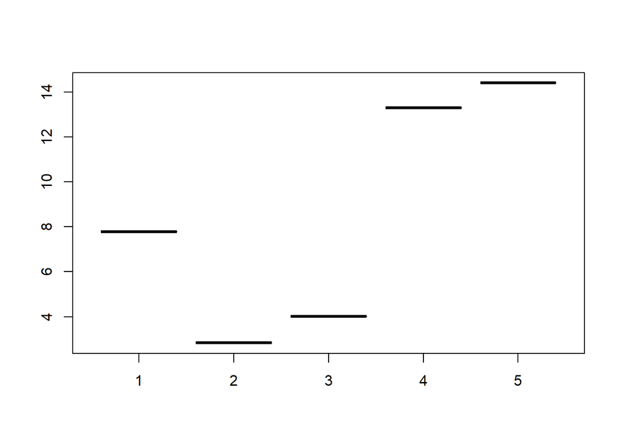

```
## [1] "combined mape boxplot is "
```

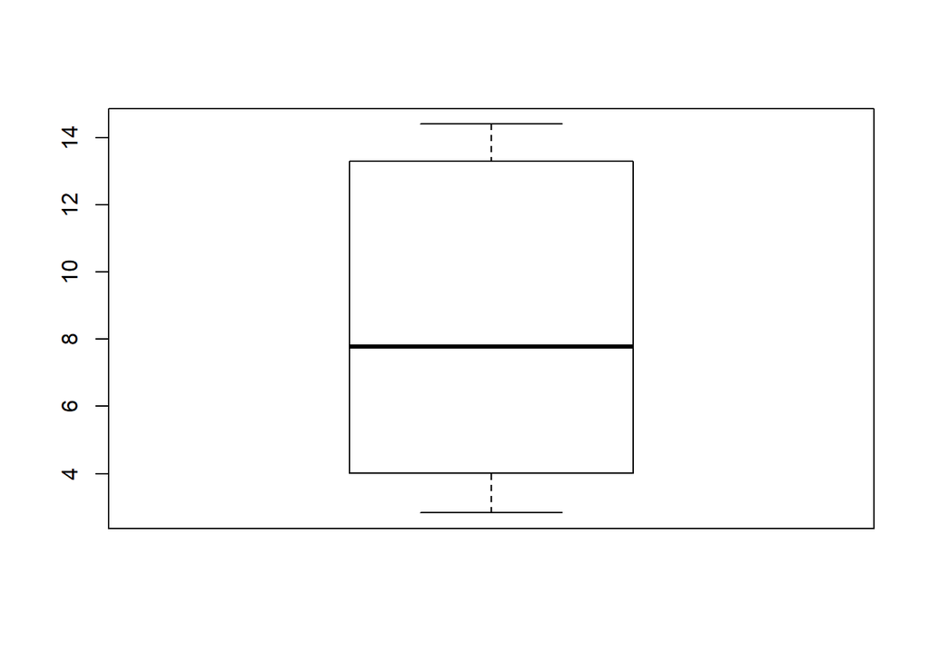

The results show that the best fit is found by using 168 hour ago values as predictors for forecasting the next day’s electricity consumption value. As we complicated our data set, the errors have gradually increased. Overall results show that the all hourly consumption is not a good way for forcasting in this type of data. Normally penalized regression is used for better estimates but in this case it was not observed.

##APPENDIX

```r
require(readr)
require(MASS)
require(dplyr)
require(glmnet)
require(ie2misc)

set.seed(256)
#data from Jan 1, 2016 to Nov 21, 2019
data_all<- read_csv("Data.csv",col_types = cols(`Consumption (MWh)` = col_number(), Date=col_date(format = "%d.%m.%Y"), Hour = col_character()))

names(data_all)[3]<-'Consumption'
#The data date will start from January 8 where Jan. 6 will be the first instance for lag_48 and Jan.1 will be for lag_168
#lag_168 will be from jan 1
lag_168<-data_all$Consumption[1:(length(data_all$Consumption)-168)]
#lag_48 will be from jan 6
lag_48<-data_all$Consumption[121:(length(data_all$Consumption)-48)]

#To start from Jan 8, the data from Jan 1 to Jan 8 are discarded and all data is combined in to a data frame
df<-cbind.data.frame(data_all[-(1:168),],lag_48,lag_168)
#reordering the columns so that consumption will be at final column
df<-df[,c(1,2,4,5,3)]
# data till 1 November 2019 is used as train set whereas data from 1 November is used for test set
df_train<-df[1:33408,]
df_test<-df[33409:length(df$Date),]
#identifying our target variables
train_results<-df_train$Consumption
test_results<-df_test$Consumption

# Use 48 hour and 168 hour lag values to have mape results without any model fitting
mape_a_using48<- mape(test_data[,3],test_data[,5])
mape_a_using168<- mape(test_data[,4],test_data[,5])

train_data<-data.frame(df_train[,(3:4)])
test_data<-data.frame(df_test)

fit_lin <- lm(train_results~.,data=train_data)
summary(fit_lin)
coef<-fit_lin$coefficients
coef
prediction <- predict(fit_lin,df_test)

mape_b<-mape(prediction,test_results)
mape_b

plot(test_results,prediction)

#FOR TRAIN
h_0<-filter(df_train,df_train$Hour=='00:00')
colnames(h_0) <- c("Date", "Hour" , "lag_48_0", "lag_168_0","cons_0")
h_1<-filter(df_train,df_train$Hour=='01:00')
colnames(h_1) <- c("Date", "Hour" , "lag_48_1", "lag_168_1","cons_1")
h_2<-filter(df_train,df_train$Hour=='02:00')
colnames(h_2) <- c("Date", "Hour" , "lag_48_2", "lag_168_2","cons_2")
h_3<-filter(df_train,df_train$Hour=='03:00')
colnames(h_3) <- c("Date", "Hour" , "lag_48_3", "lag_168_3","cons_3")
h_4<-filter(df_train,df_train$Hour=='04:00')
colnames(h_4) <- c("Date", "Hour" , "lag_48_4", "lag_168_4","cons_4")
h_5<-filter(df_train,df_train$Hour=='05:00')
colnames(h_5) <- c("Date", "Hour" , "lag_48_5", "lag_168_5","cons_5")
h_6<-filter(df_train,df_train$Hour=='06:00')
colnames(h_6) <- c("Date", "Hour" , "lag_48_6", "lag_168_6","cons_6")
h_7<-filter(df_train,df_train$Hour=='07:00')
colnames(h_7) <- c("Date", "Hour" , "lag_48_7", "lag_168_7","cons_7")
h_8<-filter(df_train,df_train$Hour=='08:00')
colnames(h_8) <- c("Date", "Hour" , "lag_48_8", "lag_168_8","cons_8")
h_9<-filter(df_train,df_train$Hour=='09:00')
colnames(h_9) <- c("Date", "Hour" , "lag_48_9", "lag_168_9","cons_9")
h_10<-filter(df_train,df_train$Hour=='10:00')
colnames(h_10) <- c("Date", "Hour" , "lag_48_10", "lag_168_10","cons_10")
h_11<-filter(df_train,df_train$Hour=='11:00')
colnames(h_11) <- c("Date", "Hour" , "lag_48_11", "lag_168_11","cons_11")
h_12<-filter(df_train,df_train$Hour=='12:00')
colnames(h_12) <- c("Date", "Hour" , "lag_48_12", "lag_168_12","cons_12")
h_13<-filter(df_train,df_train$Hour=='13:00')
colnames(h_13) <- c("Date", "Hour" , "lag_48_13", "lag_168_13","cons_13")
h_14<-filter(df_train,df_train$Hour=='14:00')
colnames(h_14) <- c("Date", "Hour" , "lag_48_14", "lag_168_14","cons_14")
h_15<-filter(df_train,df_train$Hour=='15:00')
colnames(h_15) <- c("Date", "Hour" , "lag_48_15", "lag_168_15","cons_15")
h_16<-filter(df_train,df_train$Hour=='16:00')
colnames(h_16) <- c("Date", "Hour" , "lag_48_16", "lag_168_16","cons_16")
h_17<-filter(df_train,df_train$Hour=='17:00')
colnames(h_17) <- c("Date", "Hour" , "lag_48_17", "lag_168_17","cons_17")
h_18<-filter(df_train,df_train$Hour=='18:00')
colnames(h_18) <- c("Date", "Hour" , "lag_48_18", "lag_168_18","cons_18")
h_19<-filter(df_train,df_train$Hour=='19:00')
colnames(h_19) <- c("Date", "Hour" , "lag_48_19", "lag_168_19","cons_19")
h_20<-filter(df_train,df_train$Hour=='20:00')
colnames(h_20) <- c("Date", "Hour" , "lag_48_20", "lag_168_20","cons_20")
h_21<-filter(df_train,df_train$Hour=='21:00')
colnames(h_21) <- c("Date", "Hour" , "lag_48_21", "lag_168_21","cons_21")
h_22<-filter(df_train,df_train$Hour=='22:00')
colnames(h_22) <- c("Date", "Hour" , "lag_48_22", "lag_168_22","cons_22")
h_23<-filter(df_train,df_train$Hour=='23:00')
colnames(h_23) <- c("Date", "Hour" , "lag_48_23", "lag_168_23","cons_23")
#FOR TEST
h_t_0<-filter(df_test,df_test$Hour=='00:00')
colnames(h_t_0) <- c("Date", "Hour" , "lag_48_0", "lag_168_0","cons_0")
h_t_1<-filter(df_test,df_test$Hour=='01:00')
colnames(h_t_1) <- c("Date", "Hour" , "lag_48_1", "lag_168_1","cons_1")
h_t_2<-filter(df_test,df_test$Hour=='02:00')
colnames(h_t_2) <- c("Date", "Hour" , "lag_48_2", "lag_168_2","cons_2")
h_t_3<-filter(df_test,df_test$Hour=='03:00')
colnames(h_t_3) <- c("Date", "Hour" , "lag_48_3", "lag_168_3","cons_3")
h_t_4<-filter(df_test,df_test$Hour=='04:00')
colnames(h_t_4) <- c("Date", "Hour" , "lag_48_4", "lag_168_4","cons_4")
h_t_5<-filter(df_test,df_test$Hour=='05:00')
colnames(h_t_5) <- c("Date", "Hour" , "lag_48_5", "lag_168_5","cons_5")
h_t_6<-filter(df_test,df_test$Hour=='06:00')
colnames(h_t_6) <- c("Date", "Hour" , "lag_48_6", "lag_168_6","cons_6")
h_t_7<-filter(df_test,df_test$Hour=='07:00')
colnames(h_t_7) <- c("Date", "Hour" , "lag_48_7", "lag_168_7","cons_7")
h_t_8<-filter(df_test,df_test$Hour=='08:00')
colnames(h_t_8) <- c("Date", "Hour" , "lag_48_8", "lag_168_8","cons_8")
h_t_9<-filter(df_test,df_test$Hour=='09:00')
colnames(h_t_9) <- c("Date", "Hour" , "lag_48_9", "lag_168_9","cons_9")
h_t_10<-filter(df_test,df_test$Hour=='10:00')
colnames(h_t_10) <- c("Date", "Hour" , "lag_48_10", "lag_168_10","cons_10")
h_t_11<-filter(df_test,df_test$Hour=='11:00')
colnames(h_t_11) <- c("Date", "Hour" , "lag_48_11", "lag_168_11","cons_11")
h_t_12<-filter(df_test,df_test$Hour=='12:00')
colnames(h_t_12) <- c("Date", "Hour" , "lag_48_12", "lag_168_12","cons_12")
h_t_13<-filter(df_test,df_test$Hour=='13:00')
colnames(h_t_13) <- c("Date", "Hour" , "lag_48_13", "lag_168_13","cons_13")
h_t_14<-filter(df_test,df_test$Hour=='14:00')
colnames(h_t_14) <- c("Date", "Hour" , "lag_48_14", "lag_168_14","cons_14")
h_t_15<-filter(df_test,df_test$Hour=='15:00')
colnames(h_t_15) <- c("Date", "Hour" , "lag_48_15", "lag_168_15","cons_15")
h_t_16<-filter(df_test,df_test$Hour=='16:00')
colnames(h_t_16) <- c("Date", "Hour" , "lag_48_16", "lag_168_16","cons_16")
h_t_17<-filter(df_test,df_test$Hour=='17:00')
colnames(h_t_17) <- c("Date", "Hour" , "lag_48_17", "lag_168_17","cons_17")
h_t_18<-filter(df_test,df_test$Hour=='18:00')
colnames(h_t_18) <- c("Date", "Hour" , "lag_48_18", "lag_168_18","cons_18")
h_t_19<-filter(df_test,df_test$Hour=='19:00')
colnames(h_t_19) <- c("Date", "Hour" , "lag_48_19", "lag_168_19","cons_19")
h_t_20<-filter(df_test,df_test$Hour=='20:00')
colnames(h_t_20) <- c("Date", "Hour" , "lag_48_20", "lag_168_20","cons_20")
h_t_21<-filter(df_test,df_test$Hour=='21:00')
colnames(h_t_21) <- c("Date", "Hour" , "lag_48_21", "lag_168_21","cons_21")
h_t_22<-filter(df_test,df_test$Hour=='22:00')
colnames(h_t_22) <- c("Date", "Hour" , "lag_48_22", "lag_168_22","cons_22")
h_t_23<-filter(df_test,df_test$Hour=='23:00')
colnames(h_t_23) <- c("Date", "Hour" , "lag_48_23", "lag_168_23","cons_23")
```

```r
#For hour 00:00
fit_lr_0 <- lm(h_0[,5]~.,h_0[,3:4])
pred_0<-predict(fit_lr_0,h_t_0[,3:4])
#For hour 01:00 and onwards
fit_lr_1 <- lm(h_1[,5]~.,h_1[,3:4])
pred_1<-predict(fit_lr_1,h_t_1[,3:4])
fit_lr_2 <- lm(h_2[,5]~.,h_2[,3:4])
pred_2<-predict(fit_lr_2,h_t_2[,3:4])
fit_lr_3 <- lm(h_3[,5]~.,h_3[,3:4])
pred_3<-predict(fit_lr_3,h_t_3[,3:4])
fit_lr_4 <- lm(h_4[,5]~.,h_4[,3:4])
pred_4<-predict(fit_lr_4,h_t_4[,3:4])
fit_lr_5 <- lm(h_5[,5]~.,h_5[,3:4])
pred_5<-predict(fit_lr_5,h_t_5[,3:4])
fit_lr_6 <- lm(h_6[,5]~.,h_6[,3:4])
pred_6<-predict(fit_lr_6,h_t_6[,3:4])
fit_lr_7 <- lm(h_7[,5]~.,h_7[,3:4])
pred_7<-predict(fit_lr_7,h_t_7[,3:4])
fit_lr_8 <- lm(h_8[,5]~.,h_8[,3:4])
pred_8<-predict(fit_lr_8,h_t_8[,3:4])
fit_lr_9 <- lm(h_9[,5]~.,h_9[,3:4])
pred_9<-predict(fit_lr_9,h_t_9[,3:4])
fit_lr_10 <- lm(h_10[,5]~.,h_10[,3:4])
pred_10<-predict(fit_lr_10,h_t_10[,3:4])
fit_lr_11 <- lm(h_11[,5]~.,h_11[,3:4])
pred_11<-predict(fit_lr_11,h_t_11[,3:4])
fit_lr_12 <- lm(h_12[,5]~.,h_12[,3:4])
pred_12<-predict(fit_lr_12,h_t_12[,3:4])
fit_lr_13 <- lm(h_13[,5]~.,h_13[,3:4])
pred_13<-predict(fit_lr_13,h_t_13[,3:4])
fit_lr_14 <- lm(h_14[,5]~.,h_14[,3:4])
pred_14<-predict(fit_lr_14,h_t_14[,3:4])
fit_lr_15 <- lm(h_15[,5]~.,h_15[,3:4])
pred_15<-predict(fit_lr_15,h_t_15[,3:4])
fit_lr_16 <- lm(h_16[,5]~.,h_16[,3:4])
pred_16<-predict(fit_lr_16,h_t_16[,3:4])
fit_lr_17 <- lm(h_17[,5]~.,h_17[,3:4])
pred_17<-predict(fit_lr_17,h_t_17[,3:4])
fit_lr_18 <- lm(h_18[,5]~.,h_18[,3:4])
pred_18<-predict(fit_lr_18,h_t_18[,3:4])
fit_lr_19 <- lm(h_19[,5]~.,h_19[,3:4])
pred_19<-predict(fit_lr_19,h_t_19[,3:4])
fit_lr_20 <- lm(h_20[,5]~.,h_20[,3:4])
pred_20<-predict(fit_lr_20,h_t_20[,3:4])
fit_lr_21 <- lm(h_21[,5]~.,h_21[,3:4])
pred_21<-predict(fit_lr_21,h_t_21[,3:4])
fit_lr_22 <- lm(h_22[,5]~.,h_22[,3:4])
pred_22<-predict(fit_lr_22,h_t_22[,3:4])
fit_lr_23 <- lm(h_23[,5]~.,h_23[,3:4])
pred_23<-predict(fit_lr_23,h_t_23[,3:4])

#Coefficients are
coef_hour0<-fit_lr_0$coefficients
coef_hour1<-fit_lr_1$coefficients
coef_hour2<-fit_lr_2$coefficients
coef_hour3<-fit_lr_3$coefficients
coef_hour4<-fit_lr_4$coefficients
coef_hour5<-fit_lr_5$coefficients
coef_hour6<-fit_lr_6$coefficients
coef_hour7<-fit_lr_7$coefficients
coef_hour8<-fit_lr_8$coefficients
coef_hour9<-fit_lr_9$coefficients
coef_hour10<-fit_lr_10$coefficients
coef_hour11<-fit_lr_11$coefficients
coef_hour12<-fit_lr_12$coefficients
coef_hour13<-fit_lr_13$coefficients
coef_hour14<-fit_lr_14$coefficients
coef_hour15<-fit_lr_15$coefficients
coef_hour16<-fit_lr_16$coefficients
coef_hour17<-fit_lr_17$coefficients
coef_hour18<-fit_lr_18$coefficients
coef_hour19<-fit_lr_19$coefficients
coef_hour20<-fit_lr_20$coefficients
coef_hour21<-fit_lr_21$coefficients
coef_hour22<-fit_lr_22$coefficients
coef_hour23<-fit_lr_23$coefficients

rbind(coef_hour0,coef_hour1,coef_hour2,coef_hour3,coef_hour4,coef_hour5,coef_hour6,coef_hour7,coef_hour8,coef_hour9,coef_hour10,coef_hour11,coef_hour12,coef_hour13,coef_hour14,coef_hour15,coef_hour16,coef_hour17,coef_hour18,coef_hour19,coef_hour20,coef_hour21,coef_hour22,coef_hour23)

#predictions are combined in a matrix for mape calculation

pred<-pred_0
pred[22:42]<-pred_1
pred[(21*2+1):(21*3)]<-pred_2
pred[(21*3+1):(21*4)]<-pred_3
pred[(21*4+1):(21*5)]<-pred_4
pred[(21*5+1):(21*6)]<-pred_5
pred[(21*6+1):(21*7)]<-pred_6
pred[(21*7+1):(21*8)]<-pred_7
pred[(21*8+1):(21*9)]<-pred_8
pred[(21*9+1):(21*10)]<-pred_9
pred[(21*10+1):(21*11)]<-pred_10
pred[(21*11+1):(21*12)]<-pred_11
pred[(21*12+1):(21*13)]<-pred_12
pred[(21*13+1):(21*14)]<-pred_13
pred[(21*14+1):(21*15)]<-pred_14
pred[(21*15+1):(21*16)]<-pred_15
pred[(21*16+1):(21*17)]<-pred_16
pred[(21*17+1):(21*18)]<-pred_17
pred[(21*18+1):(21*19)]<-pred_18
pred[(21*19+1):(21*20)]<-pred_19
pred[(21*20+1):(21*21)]<-pred_20
pred[(21*21+1):(21*22)]<-pred_21
pred[(21*22+1):(21*23)]<-pred_22
pred[(21*23+1):(21*24)]<-pred_23

#MAPE
mape_c<-mape(pred,test_results)
mape_c

data_wide_train<-cbind(h_0[,-c(1,2,5)],h_1[,-c(1,2,5)],h_2[,-c(1,2,5)],h_3[,-c(1,2,5)],h_4[,-c(1,2,5)],h_5[,-c(1,2,5)],h_6[,-c(1,2,5)],h_7[,-c(1,2,5)],h_8[,-c(1,2,5)],h_9[,-c(1,2,5)],h_10[,-c(1,2,5)],h_11[,-c(1,2,5)],h_12[,-c(1,2,5)],h_13[,-c(1,2,5)],h_14[,-c(1,2,5)],h_15[,-c(1,2,5)],h_16[,-c(1,2,5)],h_17[,-c(1,2,5)],h_18[,-c(1,2,5)],h_19[,-c(1,2,5)],h_20[,-c(1,2,5)],h_21[,-c(1,2,5)],h_22[,-c(1,2,5)],h_23[,-c(1,2,5)])

data_wide_test<-cbind(h_t_0[,-c(1,2,5)],h_t_1[,-c(1,2,5)],h_t_2[,-c(1,2,5)],h_t_3[,-c(1,2,5)],h_t_4[,-c(1,2,5)],h_t_5[,-c(1,2,5)],h_t_6[,-c(1,2,5)],h_t_7[,-c(1,2,5)],h_t_8[,-c(1,2,5)],h_t_9[,-c(1,2,5)],h_t_10[,-c(1,2,5)],h_t_11[,-c(1,2,5)],h_t_12[,-c(1,2,5)],h_t_13[,-c(1,2,5)],h_t_14[,-c(1,2,5)],h_t_15[,-c(1,2,5)],h_t_16[,-c(1,2,5)],h_t_17[,-c(1,2,5)],h_t_18[,-c(1,2,5)],h_t_19[,-c(1,2,5)],h_t_20[,-c(1,2,5)],h_t_21[,-c(1,2,5)],h_t_22[,-c(1,2,5)],h_t_23[,-c(1,2,5)])

data_w_train<-as.matrix(data_wide_train)
data_w_test<-as.matrix(data_wide_test)

#For hour 0
model_0<-glmnet(data_w_train,h_0[,5],family='gaussian',alpha=1,lambda = cv.glmnet(data_w_train,h_0[,5],nfolds=10,type.measure='mse',family='gaussian',alpha=1)$lambda.min)
predict_0<-predict(model_0,data_w_test)

#For hour 1 and onwards
model_1<-glmnet(data_w_train,h_1[,5],family='gaussian',alpha=1,lambda = cv.glmnet(data_w_train,h_1[,5],nfolds=10,type.measure='mse',family='gaussian',alpha=1)$lambda.min)
predict_1<-predict(model_1,data_w_test)

model_2<-glmnet(data_w_train,h_2[,5],family='gaussian',alpha=1,lambda = cv.glmnet(data_w_train,h_2[,5],nfolds=10,type.measure='mse',family='gaussian',alpha=1)$lambda.min)
predict_2<-predict(model_2,data_w_test)

model_3<-glmnet(data_w_train,h_3[,5],family='gaussian',alpha=1,lambda = cv.glmnet(data_w_train,h_3[,5],nfolds=10,type.measure='mse',family='gaussian',alpha=1)$lambda.min)
predict_3<-predict(model_3,data_w_test)

model_4<-glmnet(data_w_train,h_4[,5],family='gaussian',alpha=1,lambda = cv.glmnet(data_w_train,h_4[,5],nfolds=10,type.measure='mse',family='gaussian',alpha=1)$lambda.min)
predict_4<-predict(model_4,data_w_test)

model_5<-glmnet(data_w_train,h_5[,5],family='gaussian',alpha=1,lambda = cv.glmnet(data_w_train,h_5[,5],nfolds=10,type.measure='mse',family='gaussian',alpha=1)$lambda.min)
predict_5<-predict(model_5,data_w_test)
```

```r
model_6<-glmnet(data_w_train,h_6[,5],family='gaussian',alpha=1,lambda = cv.glmnet(data_w_train,h_6[,5],nfolds=10,type.measure='mse',family='gaussian',alpha=1)$lambda.min)
predict_6<-predict(model_6,data_w_test)

model_7<-glmnet(data_w_train,h_7[,5],family='gaussian',alpha=1,lambda = cv.glmnet(data_w_train,h_7[,5],nfolds=10,type.measure='mse',family='gaussian',alpha=1)$lambda.min)
predict_7<-predict(model_7,data_w_test)

model_8<-glmnet(data_w_train,h_8[,5],family='gaussian',alpha=1,lambda = cv.glmnet(data_w_train,h_8[,5],nfolds=10,type.measure='mse',family='gaussian',alpha=1)$lambda.min)
predict_8<-predict(model_8,data_w_test)

model_9<-glmnet(data_w_train,h_9[,5],family='gaussian',alpha=1,lambda = cv.glmnet(data_w_train,h_9[,5],nfolds=10,type.measure='mse',family='gaussian',alpha=1)$lambda.min)
predict_9<-predict(model_9,data_w_test)

model_10<-glmnet(data_w_train,h_10[,5],family='gaussian',alpha=1,lambda = cv.glmnet(data_w_train,h_10[,5],nfolds=10,type.measure='mse',family='gaussian',alpha=1)$lambda.min)
predict_10<-predict(model_10,data_w_test)

model_11<-glmnet(data_w_train,h_11[,5],family='gaussian',alpha=1,lambda = cv.glmnet(data_w_train,h_11[,5],nfolds=10,type.measure='mse',family='gaussian',alpha=1)$lambda.min)
predict_11<-predict(model_11,data_w_test)

model_12<-glmnet(data_w_train,h_12[,5],family='gaussian',alpha=1,lambda = cv.glmnet(data_w_train,h_12[,5],nfolds=10,type.measure='mse',family='gaussian',alpha=1)$lambda.min)
predict_12<-predict(model_12,data_w_test)

model_13<-glmnet(data_w_train,h_13[,5],family='gaussian',alpha=1,lambda = cv.glmnet(data_w_train,h_13[,5],nfolds=10,type.measure='mse',family='gaussian',alpha=1)$lambda.min)
predict_13<-predict(model_13,data_w_test)

model_14<-glmnet(data_w_train,h_14[,5],family='gaussian',alpha=1,lambda = cv.glmnet(data_w_train,h_14[,5],nfolds=10,type.measure='mse',family='gaussian',alpha=1)$lambda.min)
predict_14<-predict(model_14,data_w_test)

model_15<-glmnet(data_w_train,h_15[,5],family='gaussian',alpha=1,lambda = cv.glmnet(data_w_train,h_15[,5],nfolds=10,type.measure='mse',family='gaussian',alpha=1)$lambda.min)
predict_15<-predict(model_15,data_w_test)

model_16<-glmnet(data_w_train,h_16[,5],family='gaussian',alpha=1,lambda = cv.glmnet(data_w_train,h_16[,5],nfolds=10,type.measure='mse',family='gaussian',alpha=1)$lambda.min)
predict_16<-predict(model_16,data_w_test)

model_17<-glmnet(data_w_train,h_17[,5],family='gaussian',alpha=1,lambda = cv.glmnet(data_w_train,h_17[,5],nfolds=10,type.measure='mse',family='gaussian',alpha=1)$lambda.min)
predict_17<-predict(model_17,data_w_test)

model_18<-glmnet(data_w_train,h_18[,5],family='gaussian',alpha=1,lambda = cv.glmnet(data_w_train,h_18[,5],nfolds=10,type.measure='mse',family='gaussian',alpha=1)$lambda.min)
predict_18<-predict(model_18,data_w_test)

model_19<-glmnet(data_w_train,h_19[,5],family='gaussian',alpha=1,lambda = cv.glmnet(data_w_train,h_19[,5],nfolds=10,type.measure='mse',family='gaussian',alpha=1)$lambda.min)
predict_19<-predict(model_19,data_w_test)

model_20<-glmnet(data_w_train,h_20[,5],family='gaussian',alpha=1,lambda = cv.glmnet(data_w_train,h_20[,5],nfolds=10,type.measure='mse',family='gaussian',alpha=1)$lambda.min)
predict_20<-predict(model_20,data_w_test)

model_21<-glmnet(data_w_train,h_21[,5],family='gaussian',alpha=1,lambda = cv.glmnet(data_w_train,h_21[,5],nfolds=10,type.measure='mse',family='gaussian',alpha=1)$lambda.min)
predict_21<-predict(model_21,data_w_test)

model_22<-glmnet(data_w_train,h_22[,5],family='gaussian',alpha=1,lambda = cv.glmnet(data_w_train,h_22[,5],nfolds=10,type.measure='mse',family='gaussian',alpha=1)$lambda.min)
predict_22<-predict(model_22,data_w_test)

model_23<-glmnet(data_w_train,h_23[,5],family='gaussian',alpha=1,lambda = cv.glmnet(data_w_train,h_23[,5],nfolds=10,type.measure='mse',family='gaussian',alpha=1)$lambda.min)
predict_23<-predict(model_23,data_w_test)

lasso_predict<-predict_0
lasso_predict[22:42]<-predict_1
lasso_predict[(21*2+1):(21*3)]<-predict_2
lasso_predict[(21*3+1):(21*4)]<-predict_3
lasso_predict[(21*4+1):(21*5)]<-predict_4
lasso_predict[(21*5+1):(21*6)]<-predict_5
lasso_predict[(21*6+1):(21*7)]<-predict_6
lasso_predict[(21*7+1):(21*8)]<-predict_7
lasso_predict[(21*8+1):(21*9)]<-predict_8
lasso_predict[(21*9+1):(21*10)]<-predict_9
lasso_predict[(21*10+1):(21*11)]<-predict_10
lasso_predict[(21*11+1):(21*12)]<-predict_11
lasso_predict[(21*12+1):(21*13)]<-predict_12
lasso_predict[(21*13+1):(21*14)]<-predict_13
lasso_predict[(21*14+1):(21*15)]<-predict_14
lasso_predict[(21*15+1):(21*16)]<-predict_15
lasso_predict[(21*16+1):(21*17)]<-predict_16
lasso_predict[(21*17+1):(21*18)]<-predict_17
lasso_predict[(21*18+1):(21*19)]<-predict_18
lasso_predict[(21*19+1):(21*20)]<-predict_19
lasso_predict[(21*20+1):(21*21)]<-predict_20
lasso_predict[(21*21+1):(21*22)]<-predict_21
lasso_predict[(21*22+1):(21*23)]<-predict_22
lasso_predict[(21*23+1):(21*24)]<-predict_23

lambdas<-rbind(model_0$lambda,model_1$lambda,model_2$lambda,model_3$lambda,model_4$lambda,model_5$lambda,model_6$lambda,model_7$lambda,model_8$lambda,model_9$lambda,model_10$lambda,model_11$lambda,model_12$lambda,model_13$lambda,model_14$lambda,model_15$lambda,model_16$lambda,model_17$lambda,model_18$lambda,model_19$lambda,model_20$lambda,model_21$lambda,model_22$lambda,model_23$lambda)

result_lambda<-as.data.frame(cbind(df[1:24,2],lambdas))
names(result_lambda)[1]<-'Hour'
names(result_lambda)[2]<-'Lambdas'
result_lambda

betas<-cbind(model_0$beta,model_1$beta,model_2$beta,model_3$beta,model_4$beta,model_5$beta,model_6$beta,model_7$beta,model_8$beta,model_9$beta,model_10$beta,model_11$beta,model_12$beta,model_13$beta,model_14$beta,model_15$beta,model_16$beta,model_17$beta,model_18$beta,model_19$beta,model_20$beta,model_21$beta,model_22$beta,model_23$beta)
result_beta<-as.matrix(betas)
colnames(result_beta)[1:24]<-c("Hour 0 prediction","Hour 1 prediction","Hour 2 prediction","Hour 3 prediction","Hour 4 prediction","Hour 5 prediction","Hour 6 prediction","Hour 7 prediction","Hour 8 prediction","Hour 9 prediction","Hour 10 prediction","Hour 11 prediction","Hour 12 prediction","Hour 13 prediction","Hour 14 prediction","Hour 15 prediction","Hour 16 prediction","Hour 17 prediction","Hour 18 prediction","Hour 19 prediction","Hour 20 prediction","Hour 21 prediction","Hour 22 prediction","Hour 23 prediction")
result_beta
```

```r
mape_d<-mape(lasso_predict,test_results)
mape_d

print("box plot of mape_a_using48,mape_a_using168,mape_b,mape_c,mape_d respectively")
boxplot(mape_a_using48,mape_a_using168,mape_b,mape_c,mape_d)

print("combined mape boxplot is ")
mape<-c(mape_a_using48,mape_a_using168,mape_b,mape_c,mape_d)
boxplot(mape)
```